# Metadata_BARUCH_etal

Riccardo Guidi

1/4/2022

# Metadata from BARUCH et al

Paper info: Title: Fecal microbiota transplant promotes response in immunotherapy-refractory melanoma patients DOI: https://www.science.org/doi/10.1126/science.abb5920

I manually produced a table that collect all the clinical infomration present in the paper, the majority of which were actually saved as PDF.

## Is there presence of any Clinical annotation of patients?

Barush et al have some clinically annotated material that was transcribed manually into a single table (see relative folder)

```r
library(tidyverse)
df <- read_csv("raw-data/Baruch_2021/clinicalData.csv")
df
```

```
## # A tibble: 12 × 29
##    Group  Patient   AGE Gender `BRAFV600E muta… `Previous treatm… `aPD1 therapy`
##    <chr>    <dbl> <dbl> <chr>  <chr>            <chr>             <chr>
##  1 FMT d…       1    59 M      mutated          Vemurafenib       nivolumab
##  2 FMT d…       2    41 F      mutated          vemurafenic+Cobi… nivolumab
##  3 FMT r…       1    66 F      mutated          D+T;Nivo.D+T rei… <NA>
##  4 FMT r…       2    70 M      wt               Pembro;Ipi;Pembr… <NA>
##  5 FMT r…       3    78 M      wt               Pembro            <NA>
##  6 FMT r…       4    69 F      wt               unclear           <NA>
##  7 FMT r…       5    66 M      wt               Ipi+Nivo          <NA>
##  8 FMT r…       6    33 M      mutated          unclear           <NA>
##  9 FMT r…       7    66 M      mutated          Pembro;D+T        <NA>
## 10 FMT r…       8    65 M      wt               Ipi+Nivo          <NA>
## 11 FMT r…       9    35 F      wt               Nivo;Ipi;Carbopl… <NA>
## 12 FMT r…      10    44 M      wt               Ipi+Nivo          <NA>
## # … with 22 more variables: Stage <chr>, numberofDiseaseSites <dbl>,
## #   Time in CR <dbl>, baselineLDN <chr>, targetLesionDiameterSum(mm) <dbl>,
## #   baselinePDL1posCells(%) <chr>, numbCyclesInPrevaPD1 <dbl>,
## #   irAE_DuringPreviousTreatem <chr>, irAE_DuringCurrentTrial <chr>,
## #   Response by RECIST1.1_atFirstImaging <chr>,
## #   Response by iRECIST_atFirstImaging <chr>, bestResponse by iRECIS <chr>,
## #   bestRespPrevPD1 <chr>, bestRespTrial <chr>, …
```

## Is there presence of any other metadata from the paper?

### FACS

No FACS data in manuscript

### Metagenomic

16S and WGS (this concerns ComptTeam)

### Human Genetic and RNA-Seq

> **Tissue Collection** Sigmoid colon biopsy was taken at day 0 (before colonoscopy-delivered FMT) and day 31. Tumour metastasis was taken at baseline (before ICB and FMT) and on day 70.

> **RNA sequencing analysis** was based on FFPE material from the recipient biopsies. Prior to each biopsy block sectioning, the microtome was meticulously cleaned using a 70% ethanol solution followed by RNAase AWAY™ spray (Thermo Fischer, USA), and the water in the water plate were replaced. All gut and tumor biopsy blocks were sectioned 10 times, each section was 6μm thick. An expert pathologist (I.B.) reviewedthe H&E slides of each of the tumor biopsies to assess for the presence of healthy tissue. Healthy tissues were present in part of the pre-treatment sample of Recipient#3 and the post-treatment sample of Recipient#1. For those two patients, the tumor area was marked on their respective H&E slides. Following the section process, the marked tumor area was grossly dissected using a scalpel (blade No. 15) into sterile 1.5mL vials. For other tumor and gut blocks, the entire FFPE materials were sectioned directly into sterile 1.5mL vials. Aseparate vial was used for each of the samples. The vials were sealed with parafilm and were kept in -80C until RNA extraction and sequencing. Sectioned FFPE samples could spend up to 6 months in deep freeze. For RNA extraction and sequencing, FFPE samples were shipped in -80C packages to OtogeneticsCorporation (Georgia, USA). Extraction of RNA from FFPE was conducted using RNeasy FFPE kit (Qiagen, The Netherlands). The integrity and purity of total RNA were assessedusing Agilent Bioanalyzer. cDNA library was generated using Illumina truseq stranded cDNA library preparation kit (Illumina,USA,Cat# 20020594) using 500 ng of total RNA. The quality, quantity, and size distribution of the Illumina libraries were determined using an Agilent Tapestation 2200. The libraries were then sequenced using an Illumina NovaSeq 6000 sequencer according to the standard protocols. Paired-end 150 nucleotide reads were generated and checked for data quality using FastQC version 0.11.2 (Babraham Institute, UK). The reads were trimmed using TrimGalore version 0.5.0 (Babraham Institute, UK) to remove the adapters and low-quality reads, as well as poly A tail and low-quality base pairs at the 3’ ends of the reads. Reads of length shorter than 20 bp were removed from further analysis. Alignment of the trimmed fastq files to the human genome Hg38 (version 38.98) was performed via STAR version 2.6.0a (Cold Spring Harbor Laboratory, USA) usingthe following parameters *STAR –outFilterType BySJout –outFilterMultimapNmax 20 –alignSJoverhangMin 8 –alignSJDBoverhangMin 1 – outFilterMismatchNmax 999 –outFilterMismatchNoverLmax 0.6 –alignIntronMin 20 –alignIntronMax 1000000 –alignMatesGapMax 1000000 –outSAMattributes NH HI NM MD –outSAMtype BAM SortedByCoordinate.* Quantification of the gene expression was performed against Ensembl GTF (version 38.98) using STAR gene quantification mode.After read count tables were obtained for each sample, analysis was conducted using R studio version 1.1.463 (R version 3.5.1) according to standardLimma and edgeR packages workflow(57).Briefly, Ensembl IDs were matched with ENTREZ IDs, gene symbol and gene names using the Homo.sapiens package. Reads with Counts Per Million (CPM) valuesof 2 or less and readsthat appeared in only one sample were filtered out. Normalization was performed by the Trimmed Mean of M-values (TMM) method. Gene set testing was conducted using the Camera method. Gene sets databsewas the MSigDB C5 Gene Ontology (GO), which was downloaded from the Broad Institute website (http://software.broadinstitute.org/gsea/index.jsp) during November 2019. Threshold for statistically significant differed genes and gene sets was FDR≤0.05.

The data was uploaded by Peter McCaffrey to VB AWS: s3://vbx1-data/baruch-1/ GEO location of human RNA-Seq data: https://www.ncbi.nlm.nih.gov/geo/query/acc.cgi?acc=GSE162436

The GEO deposited data included a Series Matrix File, that I downloaded here, for the description of the samples /Users/riccardoguidi/Documents/GitHub/curatedMetagenomicData_MattDurrant/raw-data/Baruch_2021/RNA-Seq

```r
smdf <- read_tsv("raw-data/Baruch_2021/RNA-Seq/GSE162436_series_matrix_table.csv", skip = 32, name_repair = "universal")

names(smdf)[1] <- sub(".","",names(smdf)[1])

smdf_v2 <- smdf %>%
  mutate(Sample_title = str_replace(Sample_title,"\\!", ""))
smdf_v2
```

```
## # A tibble: 47 × 37
##    Sample_title   R1.gut.pre   R1.gut.post  R3.gut.pre  R3.gut.post  R4.gut.pre
##    <chr>          <chr>        <chr>        <chr>       <chr>        <chr>
##  1 Sample_geo_ac… GSM4952021   GSM4952022   GSM4952023  GSM4952024   GSM4952025
##  2 Sample_status  Public on D… Public on D… Public on … Public on D… Public on …
##  3 Sample_submis… Dec 01 2020  Dec 01 2020  Dec 01 2020 Dec 01 2020  Dec 01 2020
##  4 Sample_last_u… Dec 31 2020  Dec 31 2020  Dec 31 2020 Dec 31 2020  Dec 31 2020
##  5 Sample_type    SRA          SRA          SRA         SRA          SRA
##  6 Sample_channe… 1            1            1           1            1
##  7 Sample_source… Sigmoid col… Sigmoid col… Sigmoid co… Sigmoid col… Sigmoid co…
##  8 Sample_organi… Homo sapiens Homo sapiens Homo sapie… Homo sapiens Homo sapie…
##  9 Sample_charac… tissue: Sig… tissue: Sig… tissue: Si… tissue: Sig… tissue: Si…
## 10 Sample_charac… per vs post… per vs post… per vs pos… per vs post… per vs pos…
## # … with 37 more rows, and 31 more variables: R4.gut.post <chr>,
## #   R5.gut.pre <chr>, R5.gut.post <chr>, R6.gut.pre <chr>, R6.gut.post <chr>,
## #   R7.gut.pre <chr>, R7.gut.post <chr>, R8.gut.pre <chr>, R8.gut.post <chr>,
## #   R9.gut.pre <chr>, R9.gut.post <chr>, R10.gut.pre <chr>, R10.gut.post <chr>,
## #   R1.tumor.pre <chr>, R1.tumor.post <chr>, R3.tumor.pre <chr>,
## #   R3.tumor.post <chr>, R4.tumor.pre <chr>, R4.tumor.post <chr>,
## #   R5.tumor.pre <chr>, R5.tumor.post <chr>, R6.tumor.pre <chr>, …
```

```r
write_csv(smdf_v2,"curated-data/Baruch_2021/RNA-Seq/sampleMatrix.csv")
```

We also can fetched gene count already computed for **gut** and **TME** from patients

```r
library(readxl)
# gene count
gc_tme <- read_excel("raw-data/Baruch_2021/RNA-Seq/GSE162436_stranded_rev_CPM2_tumor_TMM_counts.xlsx")
gc_gut <- read_excel("raw-data/Baruch_2021/RNA-Seq/GSE162436_stranded_rev_CPM2_gut_TMM_counts.xlsx")
names(gc_tme)[1] <- "ensembl_gene_id"
names(gc_gut)[1] <- "ensembl_gene_id"

res <- read_csv("curated-data/bioMartEnsemblHsapiens.csv") #curated list of ENSMBLE gene names

gc_tme_ann <- left_join(gc_tme,res, by = "ensembl_gene_id")
gc_gut_ann <- left_join(gc_gut,res, by = "ensembl_gene_id")

write_csv(gc_tme_ann,"curated-data/Baruch_2021/RNA-Seq/geneCount_tme_ann.csv")
write_csv(gc_gut_ann,"curated-data/Baruch_2021/RNA-Seq/geneCount_gut_ann.csv")

gc_tme_ann
```

```
## # A tibble: 16,548 × 20
##    ensembl_gene_id R1_tumor_pre R1_tumor_post R3_tumor_pre R3_tumor_post
##    <chr>                  <dbl>         <dbl>        <dbl>         <dbl>
##  1 ENSG00000279457           30            22           14            13
##  2 ENSG00000228794          286           247          178           145
##  3 ENSG00000225880           31            24           18            17
##  4 ENSG00000223764            4             1            4             9
##  5 ENSG00000187634           13             9            0            15
##  6 ENSG00000188976          394           373          475           397
##  7 ENSG00000187961           74            56           84           100
##  8 ENSG00000187583            7             3            2             4
##  9 ENSG00000187642            3             2            0             0
## 10 ENSG00000188290           22            17            5            17
## # … with 16,538 more rows, and 15 more variables: R4_tumor_pre <dbl>,
## #   R4_tumor_post <dbl>, R5_tumor_pre <dbl>, R5_tumor_post <dbl>,
## #   R6_tumor_pre <dbl>, R6_tumor_post <dbl>, R7_tumor_pre <dbl>,
## #   R7_tumor_post <dbl>, R8_tumor_pre <dbl>, R8_tumor_post <dbl>,
## #   R9_tumor_pre <dbl>, R9_tumor_post <dbl>, R10_tumor_pre <dbl>,
## #   R10_tumor_post <dbl>, external_gene_name <chr>
```

```r
gc_gut_ann
```

```
## # A tibble: 15,820 × 20
##    ensembl_gene_id R1_gut_pre R1_gut_post R3_gut_pre R3_gut_post R4_gut_pre
##    <chr>                <dbl>       <dbl>      <dbl>       <dbl>      <dbl>
##  1 ENSG00000227232         10          12          4          10          5
##  2 ENSG00000279457         14          27         12          18         13
##  3 ENSG00000228794        187         153        204         176        205
##  4 ENSG00000225880         27          24         14          28         12
##  5 ENSG00000223764         32           8         35          52         36
##  6 ENSG00000187634         47          54         74          47         77
##  7 ENSG00000188976        202         249        269         242        282
##  8 ENSG00000187961         37          32         53          32         21
##  9 ENSG00000187583          7          10         20           6         17
## 10 ENSG00000188290         31          32         30          31         31
## # … with 15,810 more rows, and 14 more variables: R4_gut_post <dbl>,
## #   R5_gut_pre <dbl>, R5_gut_post <dbl>, R6_gut_pre <dbl>, R6_gut_post <dbl>,
## #   R7_gut_pre <dbl>, R7_gut_post <dbl>, R8_gut_pre <dbl>, R8_gut_post <dbl>,
## #   R9_gut_pre <dbl>, R9_gut_post <dbl>, R10_gut_pre <dbl>, R10_gut_post <dbl>,
## #   external_gene_name <chr>
```

Quick visual

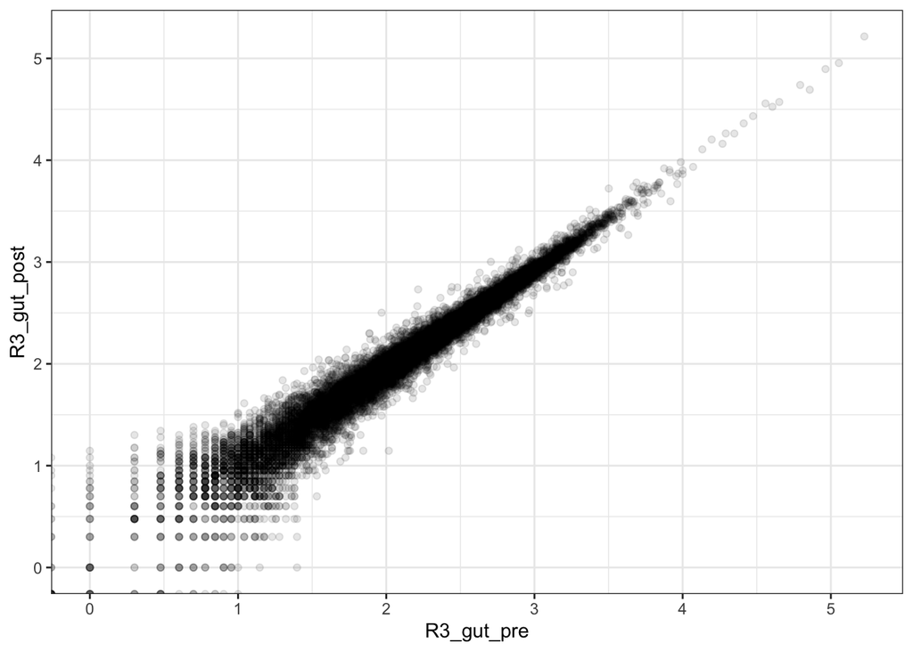

```r
p1 <- gc_gut_ann %>%
  mutate(geneID = external_gene_name, .before =  ensembl_gene_id) %>%
  mutate(across(c(3:20),log10)) %>%
  select(-last_col()) %>%
  ggplot(aes(x = R3_gut_pre, y = R3_gut_post)) +
  geom_point(alpha = 0.1) +
  theme_bw()

p2 <- gc_tme_ann %>%
  mutate(geneID = external_gene_name, .before =  ensembl_gene_id) %>%
  mutate(across(c(3:20),log10)) %>%
  select(-last_col()) %>%
  ggplot(aes(x = R3_tumor_pre, y = R3_tumor_post)) +
  geom_point(alpha = 0.1) +
  theme_bw()

p1
```

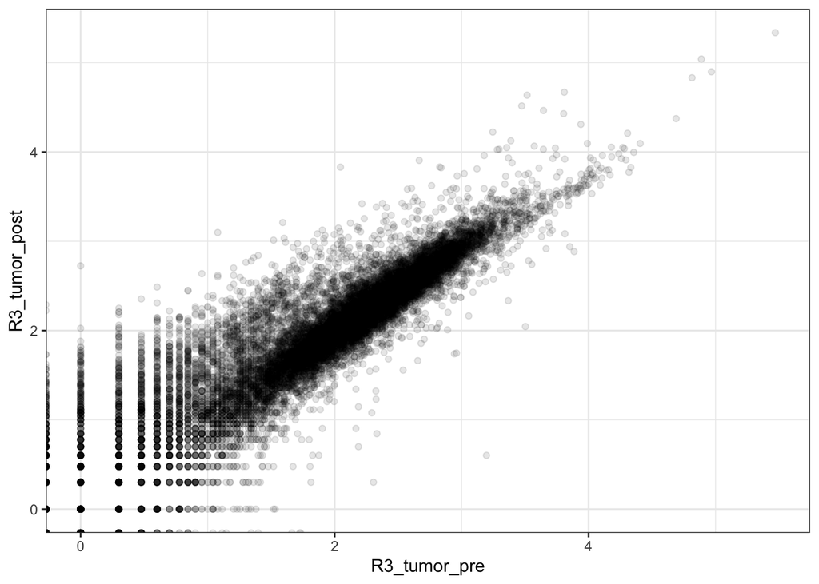

```r
p2
```

### scRNA-Seq

None executed

### Proteomic

None executed

### Metabolomic

None executed